Boxplot of USD-TRY data to examine the trend and standard deviation of the values:

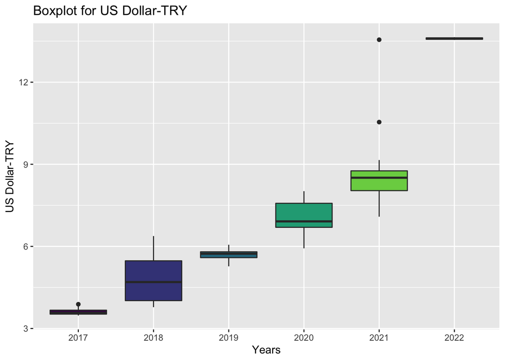

```r
ggplot(data = gold_usd_debt,aes(x=factor(Year),y=`TP DK USD S YTL`))+
  geom_boxplot(aes(fill=factor(Year)))+
  xlab("Years") + ylab("US Dollar-TRY")+
  ggtitle("Boxplot for US Dollar-TRY")+
  theme(legend.position = "none")
```

Search volume of “doviz kuru”:

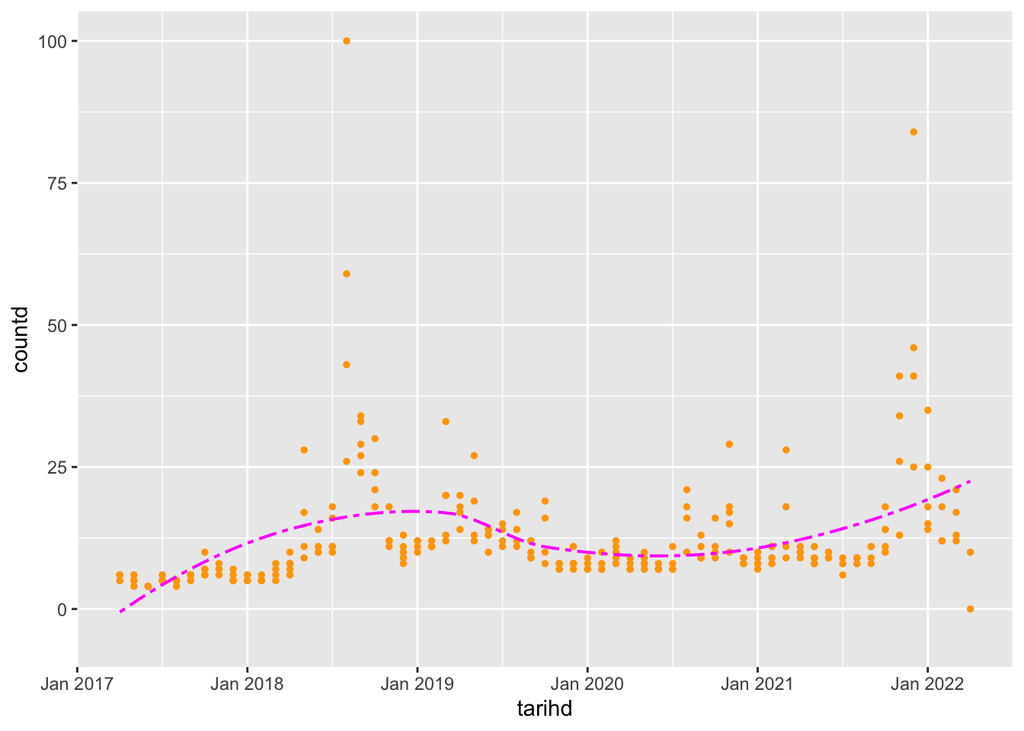

```r
doviz_kuru <- read_excel("/Users/ertugruluyar/Downloads/doviz-kuru.xlsx")
doviz_kuru$tarihd <- as.yearmon(x = doviz_kuru$tarihd)
ggplot(data = doviz_kuru)+
  geom_point(group =1,size = 1, color ='orange', aes(x=tarihd, y= countd))+
  geom_smooth(fill = NA, color="magenta",linetype = "twodash", size = 0.7, aes(x=tarihd,y= countd))
```

I chose “doviz kuru” as the possible phrase that can be relevant to the USD-TRY data because people concerned about the economic situation and their investments are likely to search this phrase. From this scatter plot and its smoothed line, we can see that there are some points that are higher in volume where we have percentage change larger than before in our data from TCMB, meaning that the speed of the change is important for the people to search for this phenomena. On the other hand, there is no obvious increasing trend as in USD-TRY data, which might be because of the phrase choice. If I had chosen the “dolar kuru” phrase rather than “doviz kuru”, I would have been highly likely to see such trend from Google Trends data.

# 3. Domestic Debt Position (Treasury)(TRY Thousand)(Monthly) data from TCMB & ‘Türkiye Borç’ search volume from Google Trends

Domestic Debt Position (Treasury)(TRY Thousand)(Monthly) data shows domestic debt situation regarding treasury of Turkey from April 2017 to February 2022.

Corresponding Line Graph and its smoothed line:

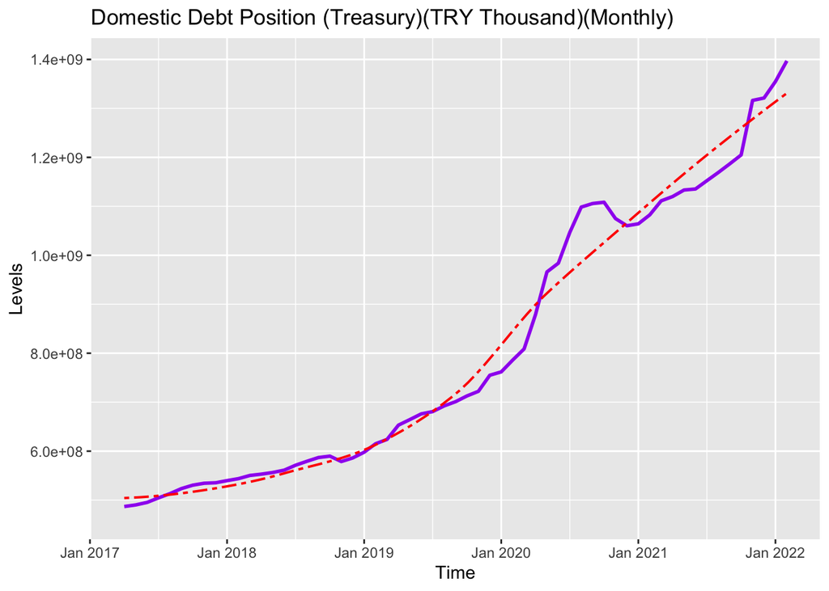

```r
ggplot(data=gold_usd_debt)+
  labs(title = "Domestic Debt Position (Treasury)(TRY Thousand)(Monthly)", x = "Time", y = "Levels" ) +
  geom_line(group=1,size=1,color='purple', aes(x=Tarih,y=`TP KB A09`))+
  geom_smooth(fill = NA, color="red",linetype = "twodash", size = 0.7, aes(x=Tarih,y=`TP KB A09`))
```

The domestic debt data shows an inreasing trend with an acceleration started approximately from the third quarter of 2019 and lasted nearly nine months. AFter having a slight decrease compared to the speed of the increase, this increase continues with less acceleration.

Histogram of Domestic Debt Position data to have a better understanding of the trend and change frequencies:

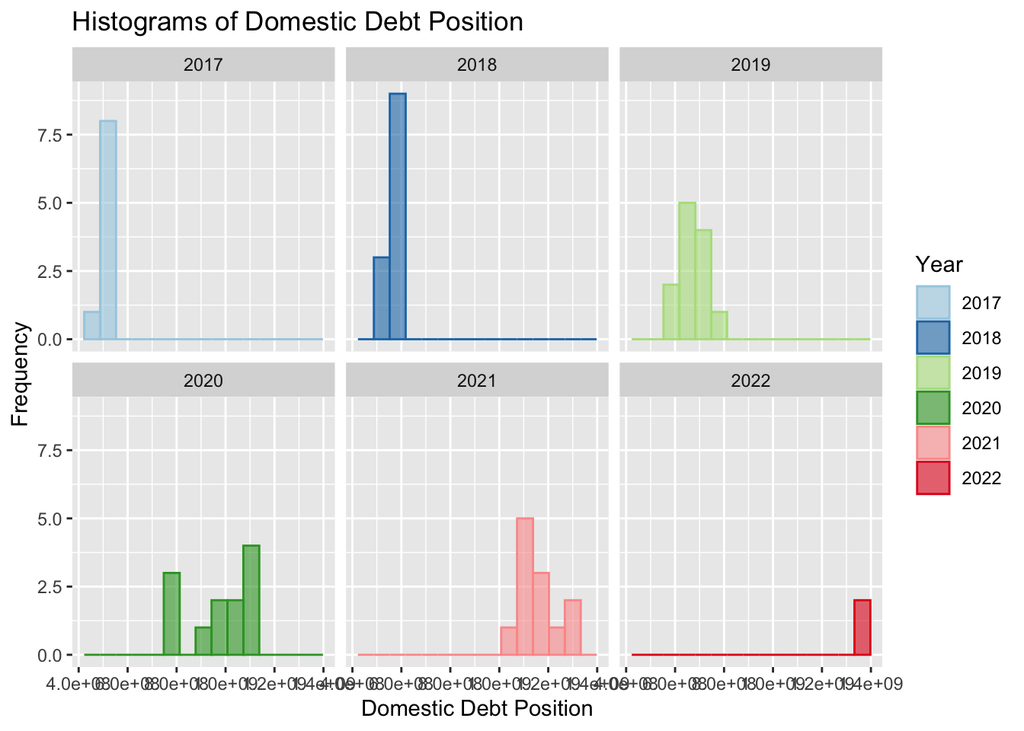

```r
ggplot(data = gold_usd_debt,aes(x =`TP KB A09` )) +
  geom_histogram(bins=15,alpha=0.6,aes(color=Year,fill=Year))+
  facet_wrap(facets= .~Year)+
  scale_color_brewer(palette = "Paired",aesthetics = c("color", "fill")) +
  labs(title = "Histograms of Domestic Debt Position",
       x = "Domestic Debt Position",
       y = "Frequency")
```

These histograms shows the increase in domestic debt position deduced from the intensity of data’s in x-axis moving from left to right and the variability of the debt position by the data’s distribution intervals, which illustrates the rapid changes started from 2019 to 2021.

Boxplot of Domestic Debt Position data to examine the trend and standard deviation of the values:

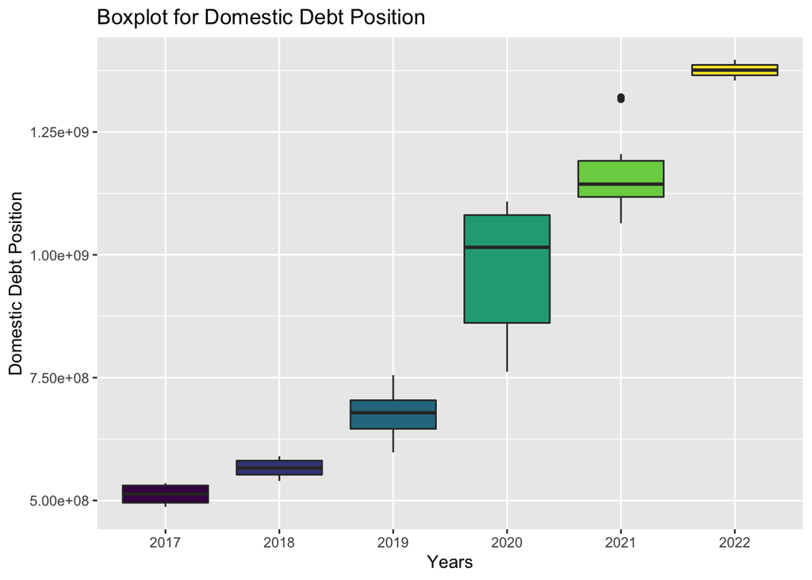

```r
ggplot(data = gold_usd_debt,aes(x=factor(Year),y=`TP KB A09`))+
  geom_boxplot(aes(fill=factor(Year)))+
  xlab("Years") + ylab("Domestic Debt Position")+
  ggtitle("Boxplot for Domestic Debt Position")+
  theme(legend.position = "none")
```

We can infer from the boxplots that the Domestic Debt regarding to Turkey’s treasury has more standart deviation in 2020, which has the constant rapid changes all year long. Moreover, we can see the maximum value of domestic debt from the upper whisker of the 2022’s boxplot. In addition, there occured an outlier in 2021.

Search volume of “Türkiye Borç”:

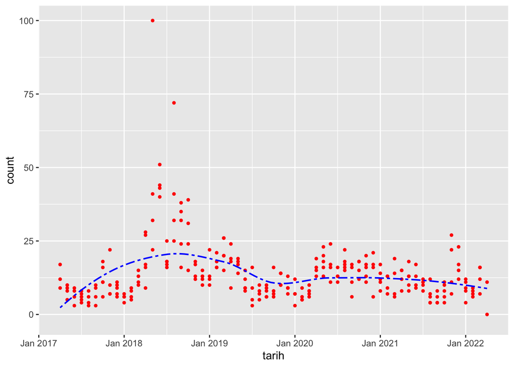

```r
borc <- read_excel("/Users/ertugruluyar/Downloads/borc.xlsx")
borc$tarih <- as.yearmon(x = borc$tarih)
ggplot(data = borc)+
  geom_point(group =1,size = 1, color ='red', aes(x=tarih, y= count))+
  geom_smooth(fill = NA, color="blue",linetype = "twodash", size = 0.7, aes(x=tarih,y= count))
```

# Comparing 3 Data Sets and Their Corresponding Phrases’ Search Volumes

To examine the correlations between each pair of Gold-USD-Debt data:

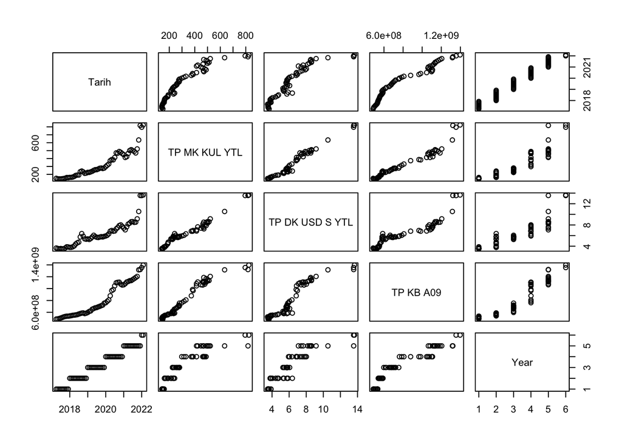

```r
plot(gold_usd_debt)
```

From the plot, we can see the obvious relations which are almost linear and have high positive correlations between them, meaning that they all follow the similar patterns and may have similar economic and political causes.

Commonalities of this three subsets of data (gold, USD, debt) and their related phrases’ search volumes: